# Part I - Airline Data Exploration

## Preliminary Wrangling

> The dataset I'm working on in this project is for the US flight data from 1987 - 2020. The datasent includes information like delays, airport, airline, date, time etc.

```python
# import all packages and set plots to be embedded inline
import numpy as np
import pandas as pd
import matplotlib.pyplot as plt
import seaborn as sb
import calendar
%matplotlib inline
import matplotlib.patches as mpatches
from datetime import datetime
```

```python
#Loading data
flightsDF = pd.read_csv("flights_data.csv")
```

```python
flightsDF.head()
```

|  | Unnamed: 0 | Year | Quarter | Month | DayofMonth | DayOfWeek | FlightDate | Reporting_Airline | DOT_ID_Reporting_Airline | IATA_CODE_Reporting_Airline | ... | Div4WheelsOff | Div4TailNum | Div5Airport | Div5AirportID | Div5AirportSeqID | Div5WheelsOn | Div5TotalGTime | Div5LongestGTime | Div5WheelsOff | Div5TailNum |
| --- | --- | --- | --- | --- | --- | --- | --- | --- | --- | --- | --- | --- | --- | --- | --- | --- | --- | --- | --- | --- | --- |
| 0 | 1295781 | 1998 | 2 | 4 | 2 | 4 | 1998-04-02 | AS | 19930 | AS | ... | NaN | NaN | NaN | NaN | NaN | NaN | NaN | NaN | NaN | NaN |
| 1 | 1125375 | 2013 | 2 | 5 | 13 | 1 | 2013-05-13 | EV | 20366 | EV | ... | NaN | NaN | NaN | NaN | NaN | NaN | NaN | NaN | NaN | NaN |
| 2 | 118824 | 1993 | 3 | 9 | 25 | 6 | 1993-09-25 | UA | 19977 | UA | ... | NaN | NaN | NaN | NaN | NaN | NaN | NaN | NaN | NaN | NaN |
| 3 | 634825 | 1994 | 4 | 11 | 12 | 6 | 1994-11-12 | HP | 19991 | HP | ... | NaN | NaN | NaN | NaN | NaN | NaN | NaN | NaN | NaN | NaN |
| 4 | 1888125 | 2017 | 3 | 8 | 17 | 4 | 2017-08-17 | UA | 19977 | UA | ... | NaN | NaN | NaN | NaN | NaN | NaN | NaN | NaN | NaN | NaN |

5 rows × 110 columns

```python
flightsDF.shape
```

```
(27000, 110)
```

> The flights data has 27000 records and 110 columns. Im not going to use all of them so I'm going to drop the columns I wont use for this analysis

#### Removing all the columns that are not usefull for analysis. For example columns that with Div they are not useful for my analysis.

```python
cols = ['Unnamed: 0','Year','Quarter','Month','DayofMonth','DayOfWeek','FlightDate','Reporting_Airline',
        'Origin','Dest','DepTime','DepDelay','ArrTime','ArrDelay','Cancelled','CancellationCode','Diverted',
        'AirTime','Flights','Distance','CarrierDelay','WeatherDelay','NASDelay','SecurityDelay','LateAircraftDelay']
flightsDF = flightsDF[cols]
```

```python
flightsDF.shape
```

```
(27000, 25)
```

```python
flightsDF.sample(10)
```

|  | Unnamed: 0 | Year | Quarter | Month | DayofMonth | DayOfWeek | FlightDate | Reporting_Airline | Origin | Dest | ... | CancellationCode | Diverted | AirTime | Flights | Distance | CarrierDelay | WeatherDelay | NASDelay | SecurityDelay | LateAircraftDelay |
| --- | --- | --- | --- | --- | --- | --- | --- | --- | --- | --- | --- | --- | --- | --- | --- | --- | --- | --- | --- | --- | --- |
| 26104 | 1682502 | 2019 | 2 | 5 | 10 | 5 | 2019-05-10 | AA | DFW | CLT | ... | NaN | 0.0 | 129.0 | 1.0 | 936.0 | NaN | NaN | NaN | NaN | NaN |
| 12574 | 1893747 | 2002 | 2 | 6 | 8 | 6 | 2002-06-08 | MQ | JFK | BOS | ... | NaN | 0.0 | 34.0 | 1.0 | 187.0 | NaN | NaN | NaN | NaN | NaN |
| 5346 | 1938 | 2019 | 2 | 6 | 17 | 1 | 2019-06-17 | AA | CAE | DFW | ... | NaN | 0.0 | 125.0 | 1.0 | 922.0 | NaN | NaN | NaN | NaN | NaN |
| 25063 | 529602 | 2016 | 2 | 6 | 9 | 4 | 2016-06-09 | OO | TUS | PHX | ... | NaN | 0.0 | 23.0 | 1.0 | 110.0 | NaN | NaN | NaN | NaN | NaN |
| 3610 | 81665 | 2013 | 2 | 5 | 10 | 5 | 2013-05-10 | AA | ORD | MSP | ... | NaN | 0.0 | 54.0 | 1.0 | 334.0 | NaN | NaN | NaN | NaN | NaN |
| 14901 | 1762453 | 1998 | 1 | 2 | 4 | 3 | 1998-02-04 | WN | ABQ | LAX | ... | NaN | 0.0 | 97.0 | 1.0 | 677.0 | NaN | NaN | NaN | NaN | NaN |
| 1934 | 1241463 | 2014 | 1 | 3 | 15 | 6 | 2014-03-15 | OO | BUR | SLC | ... | NaN | 0.0 | 103.0 | 1.0 | 574.0 | NaN | NaN | NaN | NaN | NaN |
| 5500 | 1190487 | 1990 | 3 | 7 | 2 | 1 | 1990-07-02 | US | PIT | BDL | ... | NaN | 0.0 | NaN | 1.0 | 406.0 | NaN | NaN | NaN | NaN | NaN |
| 11320 | 1657521 | 1993 | 1 | 2 | 25 | 4 | 1993-02-25 | AA | DFW | ORD | ... | NaN | 0.0 | NaN | 1.0 | 802.0 | NaN | NaN | NaN | NaN | NaN |
| 26397 | 1912746 | 2004 | 4 | 11 | 6 | 6 | 2004-11-06 | OO | LAX | OAK | ... | NaN | 0.0 | 50.0 | 1.0 | 337.0 | 58.0 | 0.0 | 0.0 | 0.0 | 0.0 |

10 rows × 25 columns

```python
flightsDF.info()
```

```
<class 'pandas.core.frame.DataFrame'>
RangeIndex: 27000 entries, 0 to 26999
Data columns (total 25 columns):
Unnamed: 0           27000 non-null int64
Year                 27000 non-null int64
Quarter              27000 non-null int64
Month                27000 non-null int64
DayofMonth           27000 non-null int64
DayOfWeek            27000 non-null int64
FlightDate           27000 non-null object
Reporting_Airline    27000 non-null object
Origin               27000 non-null object
Dest                 27000 non-null object
DepTime              26557 non-null float64
DepDelay             26557 non-null float64
ArrTime              26517 non-null float64
ArrDelay             26498 non-null float64
Cancelled            27000 non-null float64
CancellationCode     250 non-null object
Diverted             27000 non-null float64
AirTime              21406 non-null float64
Flights              27000 non-null float64
Distance             27000 non-null float64
CarrierDelay         3057 non-null float64
WeatherDelay         3057 non-null float64
NASDelay             3057 non-null float64
SecurityDelay        3057 non-null float64
LateAircraftDelay    3057 non-null float64
dtypes: float64(14), int64(6), object(5)
memory usage: 5.1+ MB
```

```python
flightsDF.describe()
```

|  | Unnamed: 0 | Year | Quarter | Month | DayofMonth | DayOfWeek | DepTime | DepDelay | ArrTime | ArrDelay | Cancelled | Diverted | AirTime | Flights | Distance | CarrierDelay | WeatherDelay | NASDelay | SecurityDelay | LateAircraftDelay |
| --- | --- | --- | --- | --- | --- | --- | --- | --- | --- | --- | --- | --- | --- | --- | --- | --- | --- | --- | --- | --- |
| count | 2.700000e+04 | 27000.000000 | 27000.000000 | 27000.000000 | 27000.000000 | 27000.000000 | 26557.000000 | 26557.000000 | 26517.000000 | 26498.000000 | 27000.000000 | 27000.000000 | 21406.000000 | 27000.0 | 27000.000000 | 3057.000000 | 3057.000000 | 3057.000000 | 3057.000000 | 3057.000000 |
| mean | 9.987625e+05 | 2004.304926 | 2.505889 | 6.518667 | 15.714370 | 3.939407 | 1343.463155 | 8.531009 | 1485.536297 | 6.174541 | 0.016556 | 0.002037 | 105.143651 | 1.0 | 728.387185 | 16.098135 | 2.736343 | 15.975466 | 0.120052 | 21.493621 |
| std | 5.767890e+05 | 9.189835 | 1.114589 | 3.444192 | 8.816548 | 1.986853 | 480.514476 | 32.435614 | 505.569232 | 34.379798 | 0.127601 | 0.045088 | 68.720911 | 0.0 | 568.506478 | 44.132440 | 18.711413 | 34.563230 | 2.222780 | 39.997374 |
| min | 1.480000e+02 | 1987.000000 | 1.000000 | 1.000000 | 1.000000 | 1.000000 | 1.000000 | -23.000000 | 1.000000 | -66.000000 | 0.000000 | 0.000000 | 2.000000 | 1.0 | 21.000000 | 0.000000 | 0.000000 | 0.000000 | 0.000000 | 0.000000 |
| 25% | 5.029945e+05 | 1997.000000 | 2.000000 | 4.000000 | 8.000000 | 2.000000 | 932.000000 | -3.000000 | 1111.000000 | -10.000000 | 0.000000 | 0.000000 | 55.000000 | 1.0 | 321.000000 | 0.000000 | 0.000000 | 0.000000 | 0.000000 | 0.000000 |
| 50% | 9.964900e+05 | 2005.000000 | 3.000000 | 7.000000 | 16.000000 | 4.000000 | 1331.000000 | 0.000000 | 1517.000000 | -1.000000 | 0.000000 | 0.000000 | 86.000000 | 1.0 | 571.000000 | 0.000000 | 0.000000 | 4.000000 | 0.000000 | 0.000000 |
| 75% | 1.500778e+06 | 2012.000000 | 3.000000 | 9.000000 | 23.000000 | 6.000000 | 1736.000000 | 7.000000 | 1913.000000 | 10.000000 | 0.000000 | 0.000000 | 134.000000 | 1.0 | 956.000000 | 16.000000 | 0.000000 | 20.000000 | 0.000000 | 27.000000 |
| max | 1.999844e+06 | 2020.000000 | 4.000000 | 12.000000 | 31.000000 | 7.000000 | 2400.000000 | 1427.000000 | 2400.000000 | 984.000000 | 1.000000 | 1.000000 | 616.000000 | 1.0 | 4983.000000 | 982.000000 | 610.000000 | 984.000000 | 67.000000 | 454.000000 |

```python
flightsDF.columns
```

```
Index(['Unnamed: 0', 'Year', 'Quarter', 'Month', 'DayofMonth', 'DayOfWeek',
       'FlightDate', 'Reporting_Airline', 'Origin', 'Dest', 'DepTime',
       'DepDelay', 'ArrTime', 'ArrDelay', 'Cancelled', 'CancellationCode',
       'Diverted', 'AirTime', 'Flights', 'Distance', 'CarrierDelay',
       'WeatherDelay', 'NASDelay', 'SecurityDelay', 'LateAircraftDelay'],
      dtype='object')
```

```python
# Checking for nulls
flightsDF.isnull().sum()
```

```
Unnamed: 0               0
Year                     0
Quarter                  0
Month                    0
DayofMonth               0
DayOfWeek                0
FlightDate               0
Reporting_Airline        0
Origin                   0
Dest                     0
DepTime                443
DepDelay               443
ArrTime                483
ArrDelay               502
Cancelled                0
CancellationCode     26750
Diverted                 0
AirTime               5594
Flights                  0
Distance                 0
CarrierDelay         23943
WeatherDelay         23943
NASDelay             23943
SecurityDelay        23943
LateAircraftDelay    23943
dtype: int64
```

#### Delay columns contain lots of null values, im going to replace them with 0s

```python
flightsDF['DepDelay'] = flightsDF['DepDelay'].fillna(0)
flightsDF['ArrTime'] = flightsDF['ArrTime'].fillna(0)
flightsDF['ArrDelay'] = flightsDF['ArrDelay'].fillna(0)
flightsDF['CarrierDelay'] = flightsDF['CarrierDelay'].fillna(0)
flightsDF['WeatherDelay'] = flightsDF['WeatherDelay'].fillna(0)
flightsDF['NASDelay'] = flightsDF['NASDelay'].fillna(0)
flightsDF['SecurityDelay'] = flightsDF['SecurityDelay'].fillna(0)
flightsDF['LateAircraftDelay'] = flightsDF['LateAircraftDelay'].fillna(0)
flightsDF[['ArrDelay','ArrTime','DepDelay','CarrierDelay','WeatherDelay','NASDelay','SecurityDelay','LateAircraftDelay']].isnull().values.any()
```

```
False
```

#### Replacing 0.0 and 1.0 with Yes and No for Cancelled variable

```python
flightsDF['Cancelled'] = flightsDF['Cancelled'].astype("str")
flightsDF  = flightsDF.replace({'Cancelled': {'0.0': 'No', '1.0': 'Yes'}})
flightsDF['Cancelled'].head(7)
```

```
0    No
1    No
2    No
3    No
4    No
5    No
6    No
Name: Cancelled, dtype: object
```

```python
#Check duplicates
flightsDF.duplicated().sum()
```

```
0
```

### What is the structure of your dataset?

> The dataset contains 27000 records and 25 columns. With more numeric columns with delays date

### What is/are the main feature(s) of interest in your dataset?

> Im most interested in flight delays

### What features in the dataset do you think will help support your investigation into your feature(s) of interest?

> Features like Year, Month, Quater and delay columns

## Univariate Exploration

```python
#Defining a function for plotting bargraph
base_color = sb.color_palette()[0]
def barplot(data,var,dimens,shape,plot_type,xticks_angle,title,plot_lables):
    base_color = sb.color_palette()[0]
    dims = (dimens[0], dimens[1])
    fig, ax = plt.subplots(figsize=dims)
    sb.set_style('darkgrid')
    if plot_type.lower() == "u":
        if shape.lower() == "v":
            sb.countplot(data=data, x=var[0],ax = ax, color = base_color).set(title=title)
        else:
            sb.countplot(data=data, y=var[0],ax = ax, color = base_color).set(title=title)
    elif plot_type.lower() == "b":
        if shape.lower() == "v":
            sb.barplot(data=data, x=var[0],y=var[1],color=base_color).set(title=title)
        else:
            sb.barplot(data=data, x=var[1],y=var[0],color=base_color).set(title=title)

    plt.xlabel(plot_lables[0]);
    plt.ylabel(plot_lables[1]);
    plt.xticks(rotation = xticks_angle)
    plt.show()
```

```python
counts = flightsDF["Reporting_Airline"].value_counts()
rep_airlines = pd.DataFrame(counts)
rep_airlines = rep_airlines.reset_index()
rep_airlines.columns = ["reporting_airline","counts"]
top5RepAir = rep_airlines.head()
top5RepAir.set_index("reporting_airline","counts", inplace = True)
top10_names = rep_airlines['reporting_airline'].head(5).tolist()
```

#### Distribution of flights over the years

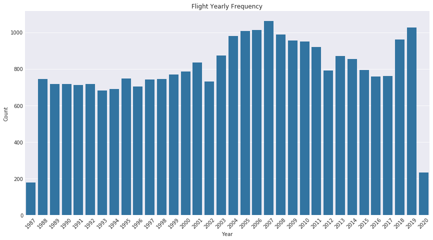

```python
barplot(flightsDF,['Year'], [14.5,7.5],"v",'u', 45,"Flight Yearly Frequency",['Year','Count'])
```

Looking into the distribution of flights over the years we can see that 2003 there was a rise of number of flights until 2007 which recorded the highest number of lights. Since 2007 the number of flights started going down. In modern times my expectation was increase of flights but thats not the case until 2018 and 2019 when they started rising up again. However the rise was cut shot due to COVID.

#### Plot For Flight Monthly Frequency

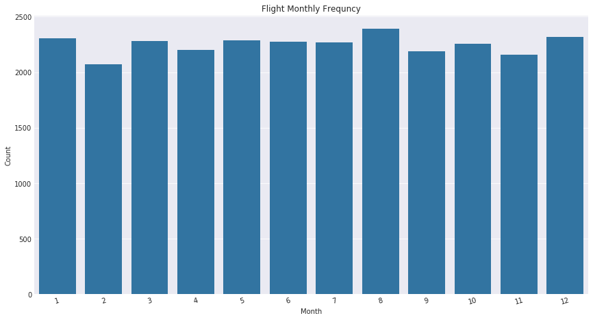

```python
barplot(flightsDF,['Month'], [14.5,7.5],"v",'u', 15,"Flight Monthly Frequncy",['Month','Count'])
```

Monthly flight distribution has few difference. But the its notable that the month of August has a slightly higher number of flights. Followed by December,January and March with also higher number of flights maybe its due to holidays like Christmas, Easter etc

#### Plot Flight Quarterly Frequency

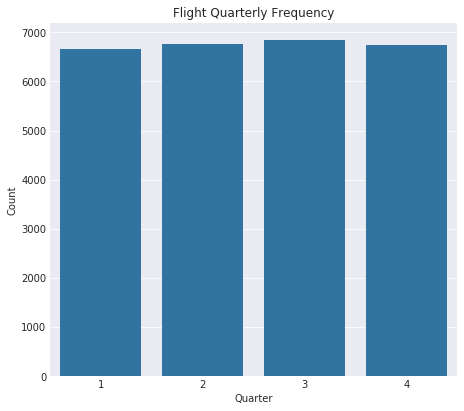

```python
barplot(flightsDF,['Quarter'], [7.3,6.5],"v",'u', 0,"Flight Quarterly Frequency",['Quarter','Count'])
```

There is no much difference in number of flights in all quaters, with the 3rd quater being slightly higher. I was expecting the forth quater to be higher because of holidays. However, I must say there is an notable increase from the 1st quater until the third.

#### Distribution of Cancellation Codes

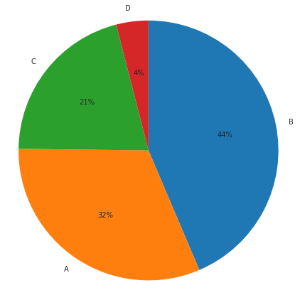

```python
plt.figure(figsize = [20, 7.5])
days_counts = flightsDF.CancellationCode.value_counts()
plt.pie(days_counts, labels = days_counts.index, startangle = 90,
        counterclock = False,autopct="%.0f%%");
plt.axis('square')
plt.show()
```

In this chat I present the distribution of Cancellation Codes and the dominant reason for cancellations is Weather(B) with Security issues the smallest only taking 4% based on my findings this was only used in 2020 which must due Health Security.

#### Plot For Destinations with over 250 flights

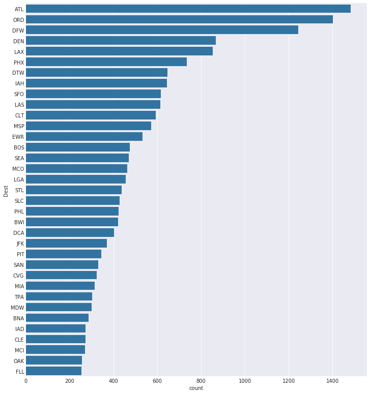

```python
dims = (12,13.5)
fig, ax = plt.subplots(figsize=dims)
dest = flightsDF[['Dest']].sort_values(by=['Dest'])
dest = dest.groupby("Dest").filter(lambda x: len(x) > 250)
order = dest['Dest'].value_counts().index
sb.countplot(data=dest, y='Dest',ax = ax,order=order,color=base_color)
```

This distribution is skewed, ATL, ORD, DFW received the highest number of flights. Based on this plot they are the biggest destinations

```python
base_color = sb.color_palette()[0]
def hist1(var,title):
    plt.figure(figsize=[12, 6.5])
    plt.hist(data = flightsDF, x = var,bins=30)
    plt.xlabel(title);
```

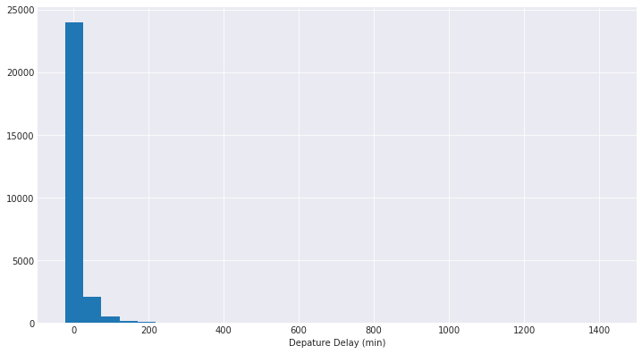

```python
hist1('DepDelay','Depature Delay (min)')
```

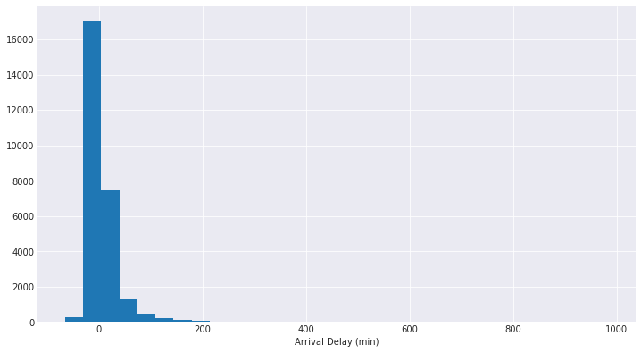

```python
hist1('ArrDelay','Arrival Delay (min)')
```

There's a long tail in the distribution, so let's put it on a log scale instead

```python
# Creating a function with log scale
def hist(var,xlabel):
    plt.figure(figsize=[12, 6.5])
    bins = 10 ** np.arange(2.2, np.log10(flightsDF[var].max())+0.02, 0.02)
    plt.hist(data = flightsDF, x = var , bins = bins)
    plt.xscale('log')
    plt.xticks([300,500, 1e3, 2e3], [300,500, '1k', '2k'])
    plt.xlabel(xlabel);
```

#### Plot for departure delay

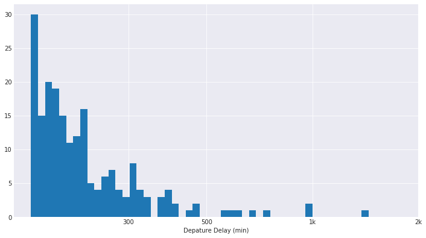

```python
hist('DepDelay','Depature Delay (min)')
```

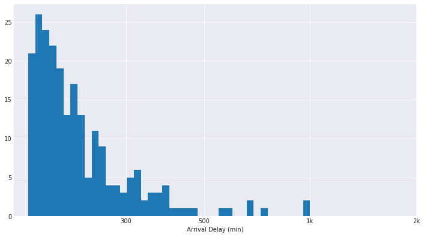

```python
hist('ArrDelay','Arrival Delay (min)')
```

Both Depature and Arrival delay have long-tailed distribution, with most of delay minutes ranging found below 500 and just afew above 500. In the first plots we could only see until 200 min but now we are able to see lowest. And it is evident that there is steep decrease from around 100 min. Based on there plots we can see that there must be a strong correlation between Arrival Delay and Departure delay as their skew look similar. But will see it in the next section

#### Flight Cancellation Frequency

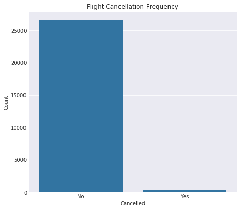

```python
barplot(flightsDF,['Cancelled'], [7.3,6.5],"v",'u', 0,"Flight Cancellation Frequency",['Cancelled','Count'])
```

The scale in the above plot contains huge figures so Im going to change it to a resonable scale

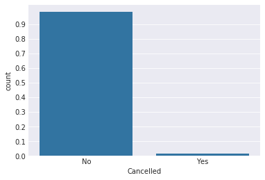

```python
#relative frequencies: cancellations and diverted flights
base_color = sb.color_palette()[0]
n=flightsDF.shape[0]
max_count=flightsDF['Cancelled'].value_counts().max()
max_prop=max_count/n
ticks=np.arange(0,max_prop,0.1)
ticks_names=['{:0.1f}'.format(v) for v in ticks]
plt.yticks(ticks*n,ticks_names)
sb.countplot(data = flightsDF, x = 'Cancelled', color = base_color)
```

The above plot clearly shows a huge skew in favor of no cancellations, the amount of cancelled flights is only 2% of the total flight counts

### Discuss the distribution(s) of your variable(s) of interest. Were there any unusual points? Did you need to perform any transformations?

> Departure and Arrival delay have scewed data, I used log to make them appear better

### Of the features you investigated, were there any unusual distributions? Did you perform any operations on the data to tidy, adjust, or change the form of the data? If so, why did you do this?

> I only changed the delay variables to remove the nulls and replace with 0

## Bivariate Exploration

```python
#Defining functions fro plotting Lineplots and scatter plots
def plot(data,cols,kind,figprams, labels,title):
    data.plot(x=cols[0], y=cols[1], kind=kind, figsize=(figprams[0],figprams[1]))
    plt.xlabel(labels[0])
    plt.ylabel(labels[1])
    plt.title(title)
    plt.show()
```

```python
#Defining function for data aggregation
def aggregateData(dataFrame,xCol,yCol):
    years = dataFrame[xCol].unique()
    countByYear = []
    for year in years:
        year_df = dataFrame[dataFrame[xCol]==year]
        count = len(year_df.index)
        countByYear.append((year, count))
    countByYearDF = pd.DataFrame(countByYear, columns=[xCol,yCol]).sort_values(xCol).reset_index().drop(['index'], axis=1)
    return countByYearDF
```

```python
#Defining function for creating subplots
def subplotsDiffData(data1,data2,kinds,plot1labels,plot2labels):
    #Subplots for
    fig = plt.figure() # create figure
    ax0 = fig.add_subplot(1, 2, 1)
    ax1 = fig.add_subplot(1, 2, 2)
    # Subplot 1: Box plot
    data1.plot(x=plot1labels[0], y=plot1labels[1],kind=kinds[0], figsize=(20, 6), ax=ax0) # add to subplot 1
    ax0.set_title('')
    ax0.set_xlabel(plot1labels[0])
    ax0.set_ylabel(plot1labels[1])
    # Subplot 2: Line plot
    data2.plot(x=plot2labels[0], y=plot2labels[1],kind=kinds[1], figsize=(20, 6), ax=ax1) # add to subplot 2
    ax1.set_title ('')
    ax1.set_xlabel(plot2labels[0])
    ax1.set_ylabel(plot2labels[1])
    plt.show()
```

#### Correlation Between DepDelay and ArrDelay

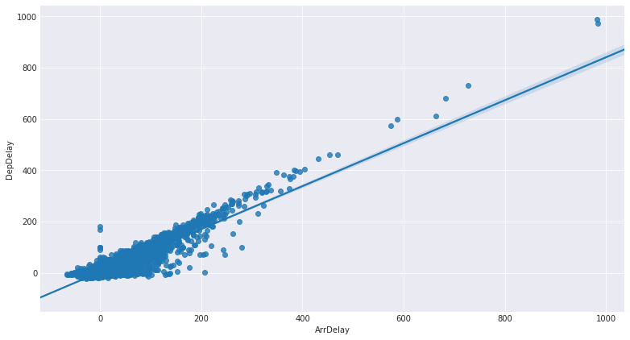

```python
plt.figure(figsize = [13,7])
scatter_data = flightsDF[flightsDF['DepDelay']<1400]
sb.regplot(data=scatter_data, x='ArrDelay',y='DepDelay')
```

```python
scatter_data[['DepDelay','ArrDelay']].corr()
```

|  | DepDelay | ArrDelay |
| --- | --- | --- |
| DepDelay | 1.000000 | 0.919914 |
| ArrDelay | 0.919914 | 1.000000 |

There is a strong correlation between Departure Delay and Arrival Delay. The correlation is 0.9. With the exception of one point that was above 1400 min in the Depature Delay.

Next I will check the relationship between Carrier Delay and Departure delay

#### Plot correlation between Carrier Delay and Depature Delay

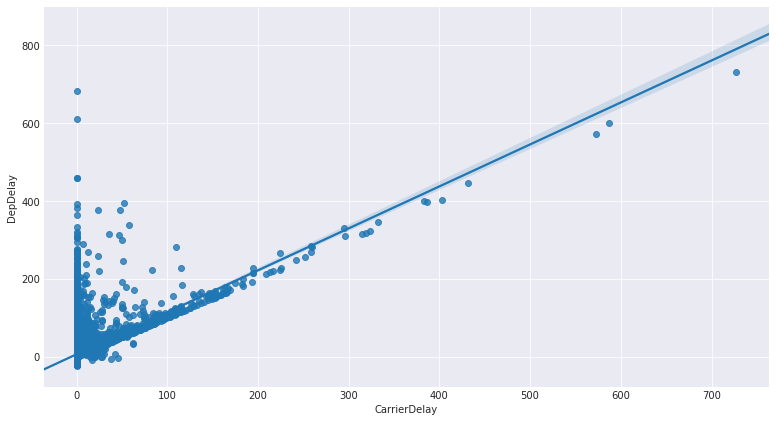

```python
plt.figure(figsize = [13,7])
carrdep = flightsDF[['CarrierDelay','DepDelay']]
carrdep = carrdep[carrdep['DepDelay'] < 900]
sb.regplot(data = carrdep, x='CarrierDelay',y='DepDelay')
```

```python
scatter_data[['CarrierDelay','DepDelay']].corr()
```

|  | CarrierDelay | DepDelay |
| --- | --- | --- |
| CarrierDelay | 1.000000 | 0.540202 |
| DepDelay | 0.540202 | 1.000000 |

There is a fair correlation between Carrier delay and Departure delay. The relationship is of 0.5. It appears that the Depature Delay apart from being influenced by Carrier Delay it has other factors that affect it.

#### Correlation between Distance and AirTime

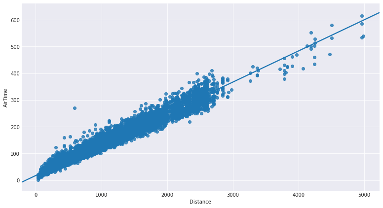

```python
plt.figure(figsize = [13,7])
sb.regplot(data=flightsDF, x='Distance',y='AirTime')
```

```python
flightsDF[['Distance','AirTime']].corr()
```

|  | Distance | AirTime |
| --- | --- | --- |
| Distance | 1.00000 | 0.98401 |
| AirTime | 0.98401 | 1.00000 |

There is strong correlation between Distance and Airtime. The correlation is of 0.98 there are just small notable outliers in the Air Tme variable.

#### Plot for Month vs Arrival Delay and Month vs Depature Delay

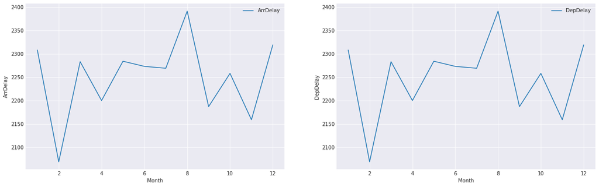

```python
month_arr = aggregateData(flightsDF,'Month','ArrDelay')
month_dep = aggregateData(flightsDF,'Month','DepDelay')
subplotsDiffData(month_arr,month_dep,['line','line'],['Month','ArrDelay'],['Month','DepDelay'])
```

#### Plot for Year vs Arrival Delay and Year vs Departure Delay

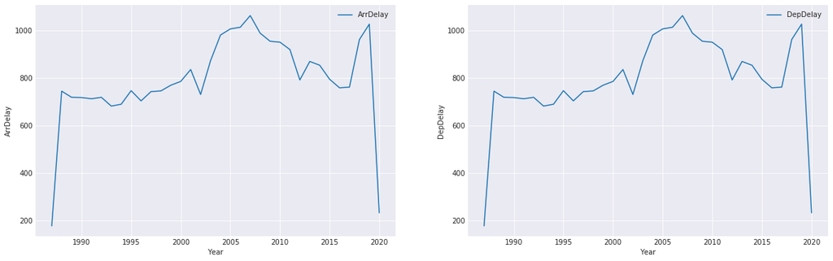

```python
year_arr = aggregateData(flightsDF,'Year','ArrDelay')
year_dep = aggregateData(flightsDF,'Year','DepDelay')
subplotsDiffData(year_arr,year_dep,['line','line'],['Year','ArrDelay'],['Year','DepDelay'])
```

There was a pick of both Arrival And Departure delays around 2006,2007 period. And it decreased after that to a sharp rising around 2019. The delays went down in 2020 due to less number of flights which must be due to lockdowns

#### Top 25 origions with highest number of Depurture Delay

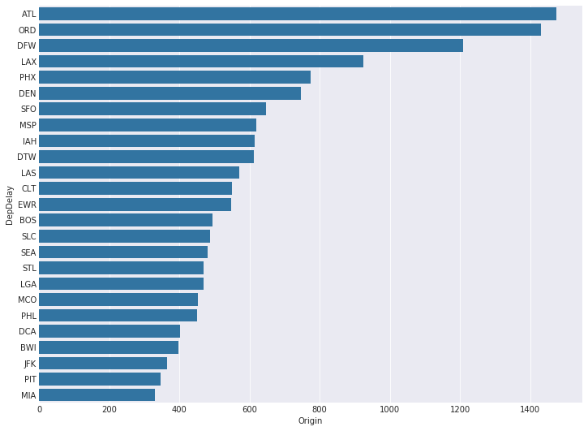

```python
depDelayByOrg = aggregateData(flightsDF,"Origin","DepDelay")
depDelayByOrg.sort_values(by="DepDelay",inplace = True,ascending = False)
top25 = depDelayByOrg.head(25)
barplot(top25,['Origin','DepDelay'], [12,9],"h",'b', 0,"",['Origin','DepDelay'])
```

#### Reporting_Airline vs WeatherDelay

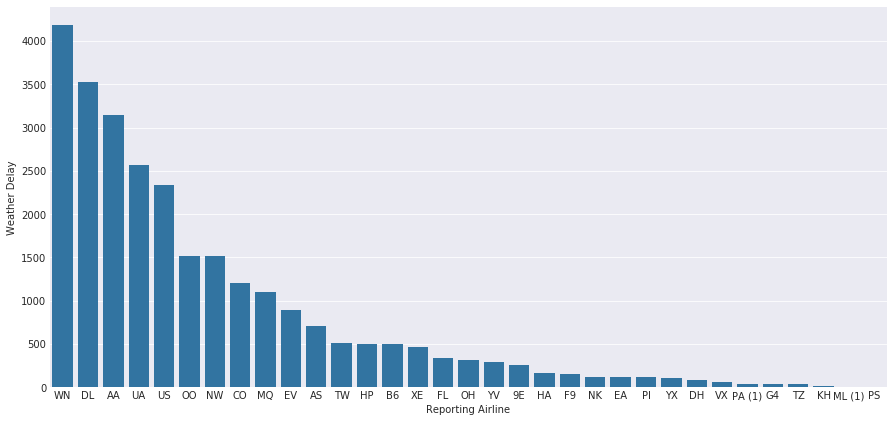

```python
#Wethere delays by Reporting_Airline
weatherDelay = aggregateData(flightsDF,"Reporting_Airline","WeatherDelay")
weatherDelay.sort_values(by='WeatherDelay', inplace=True, ascending=False)
barplot(weatherDelay,['Reporting_Airline','WeatherDelay'], [15,7],"v",'b', 0,"",['Reporting Airline','Weather Delay'])
```

### Talk about some of the relationships you observed in this part of the investigation. How did the feature(s) of interest vary with other features in the dataset?

> I expected Carrier Delay to have more effect on Depature Delay but correlation between these 2 is not very strong.

## Multivariate Exploration

```python
#Defining function for creating subplots
def subplots(data,kinds,plot1labes,plot2labels):
    #Subplots for
    fig = plt.figure() # create figure
    ax0 = fig.add_subplot(1, 2, 1)
    ax1 = fig.add_subplot(1, 2, 2)
    # Subplot 1: Box plot
    data.plot(kind=kinds[0], color='blue', vert=False, figsize=(20, 6), ax=ax0) # add to subplot 1
    ax0.set_title('')
    ax0.set_xlabel(plot1labes[0])
    ax0.set_ylabel(plot1labes[1])
    # Subplot 2: Line plot
    data.plot(kind=kinds[1], figsize=(20, 6), ax=ax1) # add to subplot 2
    ax1.set_title ('')
    ax1.set_ylabel(plot2labels[0])
    ax1.set_xlabel(plot2labels[1])
    plt.show()
```

```python
###
```

```python
top10airlinesDF = flightsDF[flightsDF['Reporting_Airline'].isin(top10_names)]
top10airlinesDF = top10airlinesDF.filter(['AirTime','Reporting_Airline','Year'], axis=1)
top10airlinesDF
airlineByYearTmp = top10airlinesDF.groupby(['Year','Reporting_Airline'])['AirTime'].mean().reset_index()
#C
airlineByYearTmp = airlineByYearTmp.pivot(index ='Year', columns ='Reporting_Airline', values =['AirTime'])
airlineByYearTmp.drop([1987,1988,1989,1990,1991,1992,1993,1994], inplace = True)
airlineByYearTmp.fillna(0, inplace=True)
```

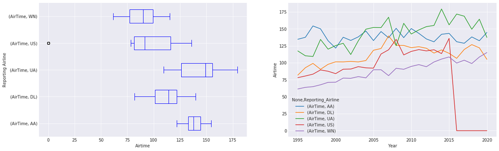

```python
subplots(airlineByYearTmp,['box','line'],['Airtime','Reporting Airline'],['Airtime','Year'])
```

Looking the above plots we can see that there is reasonable difference in the airtime by each of the 5 selected airlines. With the exception of the US that had a sharp decrease from the period of 2015 to arround 2016 where it seem to have completely stoped operating. It is clear that UA rose from second place to become the dominant from around 2011 though all of them seem to have ups and downs.

#### Comparison of Aircraft Delays From 2003 - 2020

```
Text(0.5,0,'Years')
```

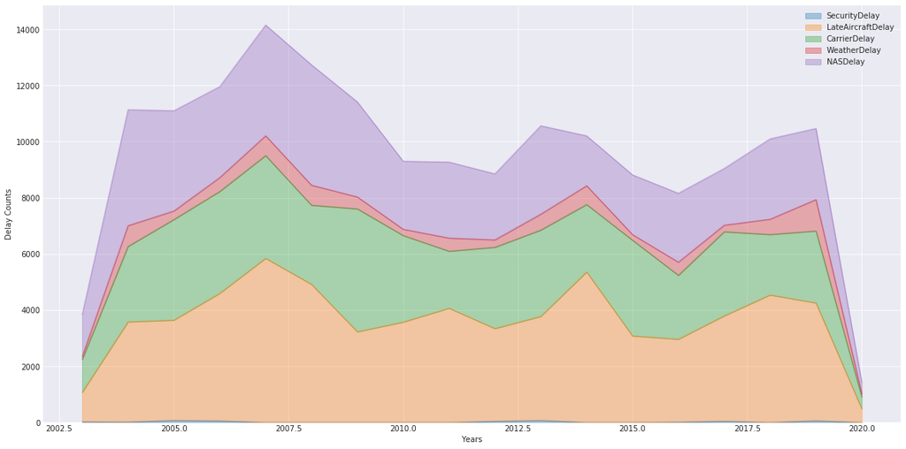

```python
delaysDF = flightsDF.filter(['Year','CarrierDelay','WeatherDelay','NASDelay','SecurityDelay','LateAircraftDelay'], axis=1)
delaysDF = delaysDF.groupby('Year')['SecurityDelay','LateAircraftDelay','CarrierDelay','WeatherDelay','NASDelay'].sum()
ax = delaysDF.loc[2003:].plot(kind='area', alpha=0.35, figsize=(20, 10))
ax.set_title('')
ax.set_ylabel('Delay Counts')
ax.set_xlabel('Years')
```

#### Monthly Flight Cancellation

```
Text(0,0.5,'Flights')
```

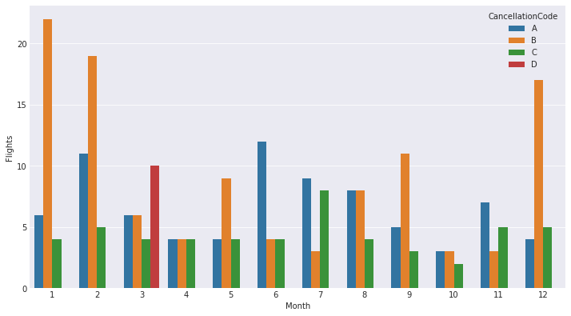

```python
plt.figure(figsize = [12,6.5])
bar_data = flightsDF.groupby(['Month','CancellationCode'])['Flights'].sum().reset_index()
sb.barplot(data=bar_data, x='Month',y='Flights',hue='CancellationCode');
plt.title='Monthly Flight Cancelations'
plt.ylabel("Flights")
```

January, February and December are the months mostly affected by weather cancellations. Security issues cancellation doesnt usually occur. Weather cancelation is found in all months with July, October and November recording the lowest

#### Yearly Flight Cancellation

```
Text(0,0.5,'Flights')
```

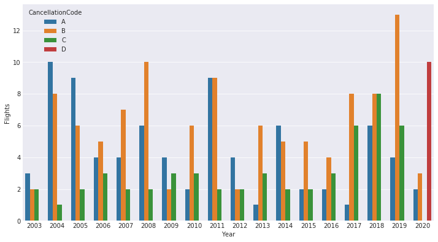

```python
plt.figure(figsize = [12,6.5])
bar_data = flightsDF.groupby(['Year','CancellationCode'])['Flights'].sum().reset_index()
sb.barplot(data=bar_data, x='Year',y='Flights',hue='CancellationCode');
plt.title='Yearly Flight Cancelations'
plt.ylabel("Flights")
```

It is clear that over the years Weather(B) has been dominating flight cancellations with the highest number of cancellations recordered in the year 2019. Carrier(A) cancellation is also seen dominating in few years sometimes equaling Weather(B). But based on what we have seen in both monthly and yearly cancelations we conclude that weather is the highest cause of many cancellations.

#### Reporting Arline Flight Cancellation

```
Text(0,0.5,'Flights')
```

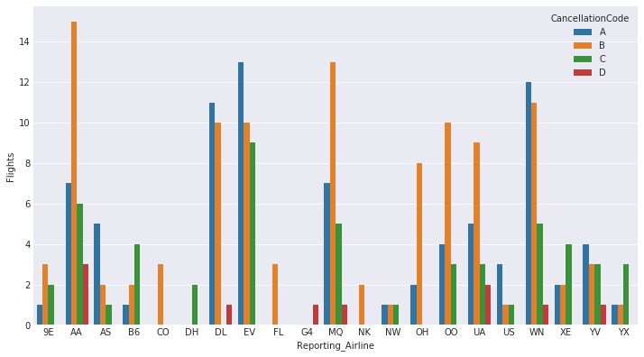

```python
plt.figure(figsize = [12,6.5])
bar_data = flightsDF.groupby(['Reporting_Airline','CancellationCode'])['Flights'].sum().reset_index()
sb.barplot(data=bar_data, x='Reporting_Airline',y='Flights',hue='CancellationCode');
plt.title='Monthly Flight Cancelations'
plt.ylabel("Flights")
```

Almost all Airlines were affected with Carrier cancellation (A) and only 7 affected by Security issues(D)

#### Monthly flight time by Airline for 5 top Airlines

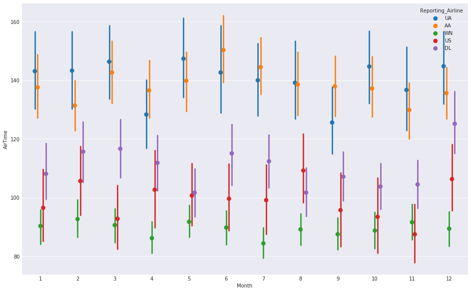

```python
plt.figure(figsize = [16,10])
top10_names = rep_airlines['reporting_airline'].head(5).tolist()
top10_names
top10airlinesDF = flightsDF[flightsDF['Reporting_Airline'].isin(top10_names)]
top10airlinesDF = top10airlinesDF.filter(['AirTime','Reporting_Airline','Month'], axis=1)
sb.pointplot(data = top10airlinesDF, x = 'Month', y = 'AirTime', hue = 'Reporting_Airline',linestyles = '', dodge = 0.3);
```

### Talk about some of the relationships you observed in this part of the investigation. Were there features that strengthened each other in terms of looking at your feature(s) of interest?

> Its interesting to see that weather has highest number of cancellations and also security issues were only a cause of cancellations in 2020 in the month of March, the month when Covid lockdowns started